# Classification with Linear Discriminant Analysis (LDA)

# Our scenario

We have existing observations

$$(x_1, C_1), ... (x_n, C_n)$$

where the $C_i$ are **categories**.

Given a new observation $x_{new}$, how do we predict $C_{new}$?

## A simple example

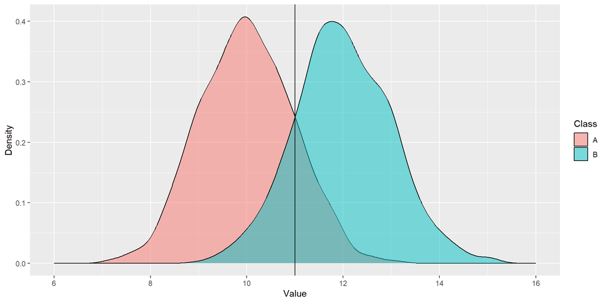

## How about cutting in the middle?

```r
dat %>%
  mutate(
    pred_class = if_else(
      val > 11,
      "B",
      "A"
    )
  ) %>%
  count(Class, pred_class)
```

```
# A tibble: 4 × 3
  Class pred_class     n
  <chr> <chr>      <int>
1 A     A            842
2 A     B            158
3 B     A            154
4 B     B            846
```

- What’s our sensitivity?
- What’s our specificity?

## What if we move the cutoff?

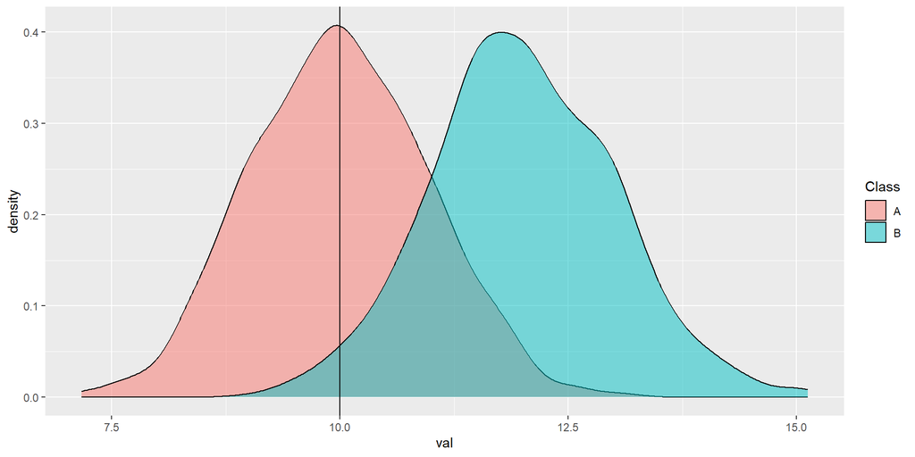

Why would we choose an “uneven” cutoff?

# How’d we do?

```r
dat %>%
  mutate(
    pred_class = if_else(
      val > 10,
      "B",
      "A"
    )
  ) %>%
  count(Class, pred_class)
```

```
# A tibble: 4 × 3
  Class pred_class     n
  <chr> <chr>      <int>
1 A     A            507
2 A     B            493
3 B     A             23
4 B     B            977
```

## LDA, in General

To perform **classification** with **Linear Discriminant Analysis**, we choose the *best dividing line* between the two classes.

The Big Questions

- What is our definition of **best**?
- What if we allow the line to “wiggle”?

## Example

Let’s keep hanging out with the insurance dataset.

Suppose we want to use information about insurance charges to predict whether someone is a smoker or not.

```r
ins <- read_csv("https://www.dropbox.com/s/bocjjyo1ehr5auz/insurance.csv?dl=1")

ins <- ins %>%
  mutate(
    smoker = factor(smoker)
  ) %>%
  drop_na(smoker)
```

Quick Quiz

What do we have to change?

The model?

The recipe?

The workflow?

The fit?

## Step 1: Change the model!

```r
lda_mod <- discrim_linear() %>%
  set_engine("MASS") %>%
  set_mode("classification")
```

## Step 2: Fit our model!

```r
lda_fit_1 <- lda_mod %>%
  fit(smoker ~ charges,
      data = ins)
```

```r
lda_fit_1
```

```
parsnip model object

Call:
lda(smoker ~ charges, data = data)

Prior probabilities of groups:
    no    yes
0.7981 0.2019

Group means:
    charges
no     7528
yes   31152

Coefficients of linear discriminants:
            LD1
charges 0.00014
```

## Finding the decision boundary

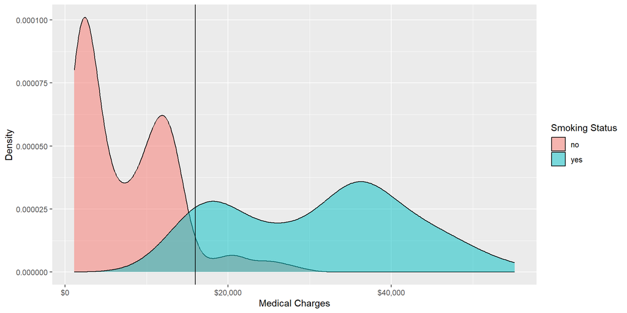

## Step 3: Make some predictions!

```r
preds <- predict(lda_fit_1,
                 new_data = ins)

ins <- ins %>%
  mutate(
    pred_smoker = preds$.pred_class
  )

ins %>%
  accuracy(truth = smoker,
           estimate = pred_smoker)
```

```
# A tibble: 1 × 3
  .metric  .estimator .estimate
  <chr>    <chr>          <dbl>
1 accuracy binary         0.921
```

What if we want to use more than one predictor?

## Adding `age` as a predictor

```r
lda_fit_2 <- lda_mod %>%
  fit(smoker ~ charges + age, data = ins)

lda_fit_2
```

```
parsnip model object

Call:
lda(smoker ~ charges + age, data = data)

Prior probabilities of groups:
    no    yes
0.7981 0.2019

Group means:
    charges   age
no     7528 38.30
yes   31152 36.62

Coefficients of linear discriminants:
               LD1
charges  0.0001718
age     -0.0449953
```

## Finding classification equation

```r
lda_fit_2$fit$scaling
```

```
               LD1
charges  0.0001718
age     -0.0449953
```

Predict “smoker” if Score > 0

## Let’s Plot it!

```r
coefficients <- lda_fit_2$fit$scaling

my_slope = coefficients[1] /
              (-1 *coefficients[2])
```

```r
ins %>%
  ggplot(mapping = aes(x = charges, y = age, color = smoker)) +
  geom_point() +
  geom_abline(mapping = aes(slope = my_slope, intercept = 0),
              lwd = 1.5) +
  scale_x_continuous(labels = label_dollar()) +
  labs(x = "Medical Charges",
       y = "Age",
       color = "Smoking Status")
```

## Let’s Plot it!

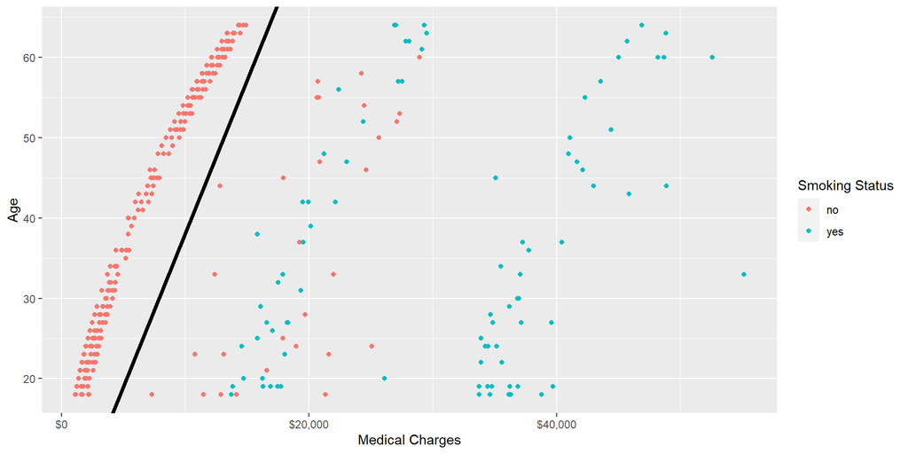

## Try it! (you know the drill…)

Open `Activity-Classification-LDA.qmd`

Select the best LDA model for predicting smoker status.

Compare the accuracy to your KNN and Logistic Regression models (from last class).

## Quadratic Discriminant Analysis

One more time: wiggly style

## QDA

What if we allow the separating line to be non-linear?

```r
qda_mod <- discrim_regularized(frac_common_cov = 0) %>%
  set_engine('klaR') %>%
  set_mode('classification')
```

In this case, we allow the data in the different categories to have different variances.

## An example scenario

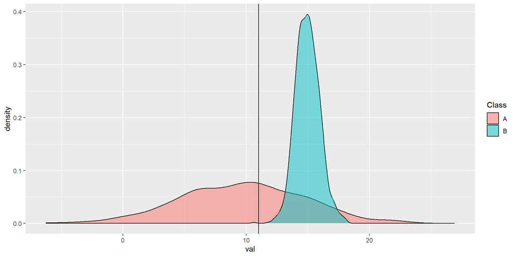

## Let’s visualize the relationship

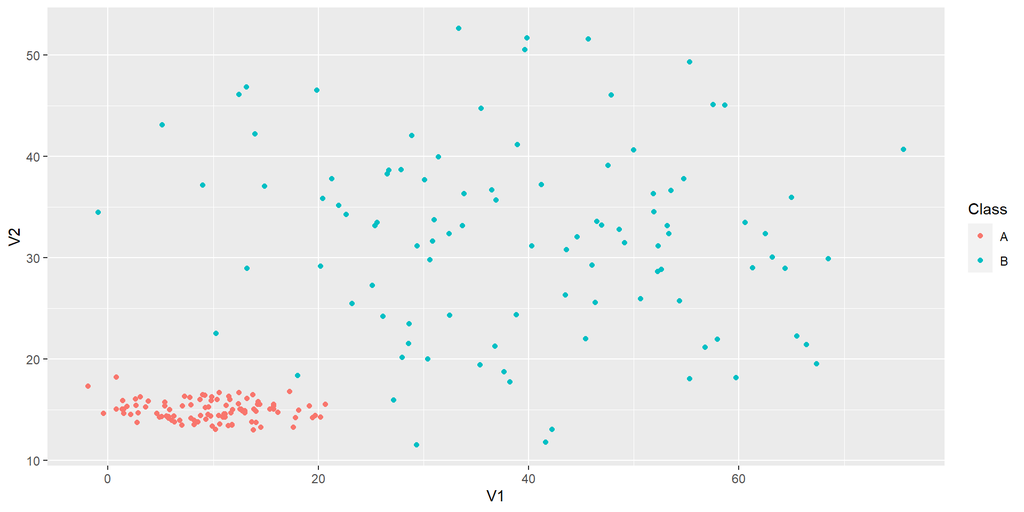

## Visualizing the decision boundary

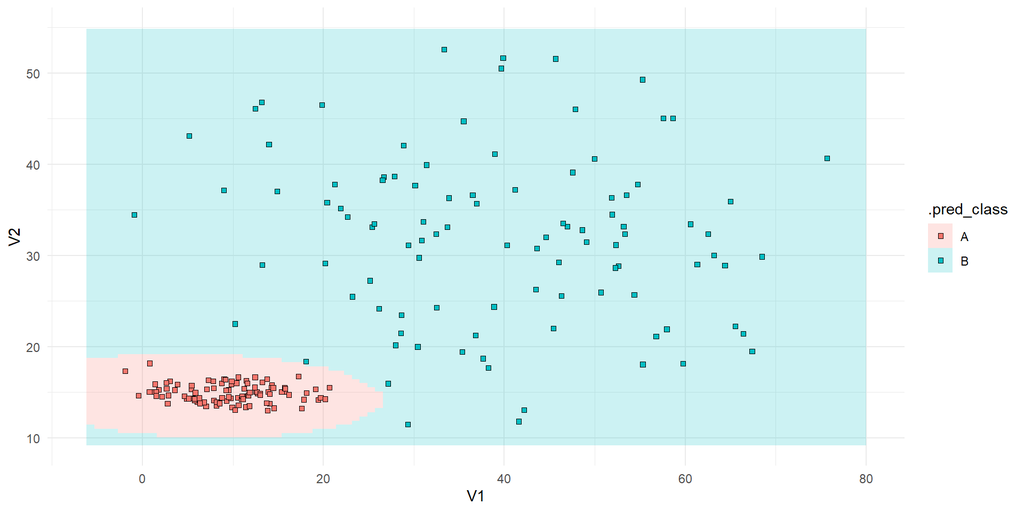

## Try it!

Open `Activity-Classification-LDA.qmd` again

Select the best QDA model

Compare to prior models